# An Analysis of Severe Weather and Climate Events between 1950-2011 and the Identification of those which Incurred the Most Human and Economic Losses.

Ray Lugo, Jr.

February 17, 2017

## Synopsis

The [U.S. National Oceanic and Atmospheric Administration](https://www.ncdc.noaa.gov/climate-information/extreme-events) (NOAA) Storm database contains observations of weather events across the United States. The dataset used in this report includes observations of weather events from 1950 - 2011. The purpose of this analysis is to determine the weather events which cause the highest number of casualties (injury and death) to the human population as well as the most damage caused to property and crops in terms of estimated cost of the loss, repair or replacement.

During exploratory analysis, we have determined that the data required further processing to acheive normalization, as there was substantial variance found in the categorization of the Events themselves which could lead to inaccuracy. Steps were taken to eliminate the variance where necessary and mitigate risk.

## Environment Prep and Session Report

The R packages used for this analysis include *Tidyverse (dplyr, ggplot2, etc.), reshape2, data.table, stringi and gridExtra*. Please refer to the included session information which provides details on the versions of each package. For this session, the scientific notation option has been disabled in order to display monetary values.

```r
library(tidyverse)
library(reshape2)
library(data.table)
library(stringi)
library(gridExtra)
library(knitr)
library(xtable)

options(scipen = 999)
```

[session information not shown]

## Data Loading

Due to the number of records and the size of the data file, “fread” was chosen for its data ingestion speed which minimizes the time needed to populate the data table. Initial data loading finishes in under 40 secs with subsequent loads completing in under 3 secs on average.

Using “fread”, we optimised speed and use of space by specifying the data fields to be imported from the CSV file prior to starting the process and this prevented the need to import extaneous fields such as the comments which are not required for this analysis. The BGN_DATE field contains a date stored in the format “YYYYMMDD”. For the purpose of this analysis we converted that data into an actual “Date” field and also created a new field which holds only the “YEAR” part of each BGN_DATE.

```r
data_dir <- paste0(getwd(),"/data")
file_url <- "http://d396qusza40orc.cloudfront.net/repdata%2Fdata%2FStormData.csv.bz2"
source_file <- paste(data_dir,"repdata_data_StormData.csv.bz2", sep = "/")
csvStormData <- paste(data_dir,"repdata_data_StormData.csv", sep = "/")

if (!file.exists(csvStormData)) {
    if (!file.exists(source_file)) {
        if (!dir.exists(data_dir)) {
            dir.create(data_dir)
        }
        download.file(file_url, source_file)
    }
    unzip(source_file, "repdata_data_StormData.csv", list = F, junkpaths = F,exdir = "./data", unzip = "internal")
}

# data File processing
keepCols <- c("BGN_DATE","EVTYPE","FATALITIES","INJURIES","PROPDMG", "PROPDMGEXP", "CROPDMG", "CROPDMGEXP")

stormData <- fread(file = csvStormData, sep = ",", header = T, select = keepCols, na.strings = "NA", verbose = T, autostart = T,
                   strip.white = T, data.table = T, quote = '\"', stringsAsFactors = F, showProgress = T)
```

[output not shown]

```r
#char to date field conversion
stormData$BGN_DATE <- as.Date(stormData$BGN_DATE,"%m/%d/%Y")
#create YEAR field from BGN_DATE
stormData$YEAR <- year(stormData$BGN_DATE)
```

The EVTYPE (Event Type) field contains “Event”" categories but it seems that the reporting was inconsistent and created variance in the catagory values themselves. The values for the most significant event types were normalized in order to ensure that the results of each calculations is based on complete and accurate subsets of data. This required several iterations until the “target” events were identified and the event values were corrected.

During the exploratory analysis phase, a time series plot of the events with the highest number of casualties revealed that only two events were being reported initially and that the constant number of events recorded began around 1993. All plots and results are then based off of the subset of data from 1993 - 2011, in order to minimize outliers and to provide a comparison where all events have an equal number of years worth of observations for 1:1 comparisons.

```r
#cleanup pertinent EVTYPE variants using regexes before analysis for more accuracy
stormData$EVTYPE <- stri_replace(stormData$EVTYPE, "THUNDERSTORM", regex = "(.)*?(A-Z)?T\\w+\\sWIN(D)?(S)?\\D?(.*)?")
stormData$EVTYPE <- stri_replace(stormData$EVTYPE, "THUNDERSTORM", regex = "(.*)THUNDERSTORM(.*)")
stormData$EVTYPE <- stri_replace(stormData$EVTYPE, "FLASH FLOODS", regex = "(.*)?FLOOD(.*)?")
stormData$EVTYPE <- stri_replace(stormData$EVTYPE, "EXTREME HEAT", regex = "(.*)HEAT(.*)")
stormData$EVTYPE <- stri_replace(stormData$EVTYPE, "TORNADO", regex = "(.*)TORNADO(.*)")
stormData$EVTYPE <- stri_replace(stormData$EVTYPE, "HAIL", regex = "(.*)HAIL(.*)")
stormData$EVTYPE <- stri_replace(stormData$EVTYPE, "HURRICANE", regex = "(.*)HURRICANE(.*)")
stormData$EVTYPE <- stri_replace(stormData$EVTYPE, "TROPICAL STORM", regex = "(.*)TROPICAL STORM(.*)")
```

## Results

#### Across the United States, which types of events (as indicated in the EVTYPE variable) are most harmful with respect to population health?

From 1993-2011, Tornados were responsible for 25K casualties, followed by Extreme Heat with 12.3K and Flash Flooding with 10.1K.

```r
#The majority of data reporting for all EVTYPES starts around 1993.
#Using that as a selection filter on YEAR to keep tornados from becoming an outlier.
#limiting records to ones that have FATALITIES or INJURIES
population_health_1993 <- stormData %>%
    filter(YEAR >= 1993 & (FATALITIES != 0 | INJURIES != 0)) %>%
    select(EVTYPE, FATALITIES, INJURIES) %>%
    group_by(EVTYPE) %>%
    summarize(FATALITIES = sum(FATALITIES), INJURIES = sum(INJURIES), CASUALTIES = sum(FATALITIES + INJURIES)) %>%
    arrange(desc(CASUALTIES))
```

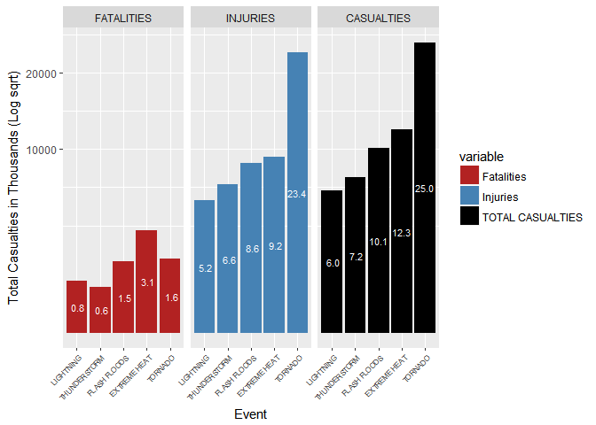

```r
top_5_pop_events <- melt(population_health_1993[1:5,],id.vars = "EVTYPE")
levels(top_5_pop_events$EVTYPE) <- population_health_1993[1:5,]$EVTYPE

bar_population_health_Top_5 <- ggplot(top_5_pop_events, aes(x = reorder(EVTYPE, value), y = value, fill = variable, label = format(round(value/1000,1), big.mark = ",", scientific = F))) +
    geom_bar(stat = "identity") +
    geom_text(size = 3, color = "white", position = position_stack(vjust = 0.5)) +
    scale_y_sqrt() +
    facet_grid(.~variable) +
    scale_fill_manual(values = c("firebrick","steelblue","black"), labels = c("Fatalities", "Injuries", "TOTAL CASUALTIES")) +
    theme(axis.text.x = element_text(angle = 45, size = 6, hjust = 1)) +
    labs(main = "Top 5 Events with Highest Casualties 1993 - 2011", x = "Event", y = "Total Casualties in Thousands (Log sqrt)")

bar_population_health_Top_5
```

#### Across the United States, which types of events have the greatest economic consequences?

Flash Floods caused an estimated $157.6B in damage to property and crops, followed by Hurricanes with S44.3B and Tornados with $16.5B.

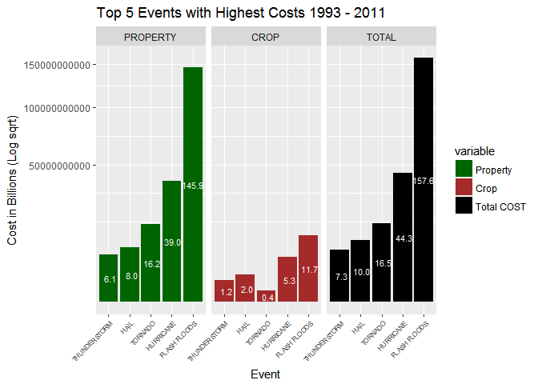

```r
#Question 2

#create tables to hold damage code and corresponding magnitude for PROP and CROP.
propDamageCalc <- data.frame(
    PROPDMGEXP = c("K", "M", "B"),
    PROPDMGMULT = c(1000,1000000,1000000000),
    stringsAsFactors = F
)

cropDamageCalc <- data.frame(
    CROPDMGEXP = c("K", "M", "B"),
    CROPDMGMULT = c(1000,1000000,1000000000),
    stringsAsFactors = F
)

damageData <- stormData %>%
    filter(YEAR >= 1993 & (PROPDMG != 0 | CROPDMG != 0)) %>%
    select(EVTYPE, PROPDMG, PROPDMGEXP, CROPDMG, CROPDMGEXP)

damageData <- inner_join(damageData, propDamageCalc, by = "PROPDMGEXP")
damageData <- inner_join(damageData, cropDamageCalc, by = "CROPDMGEXP")

damageData <- mutate(damageData, PROPDMGCOST = PROPDMG * PROPDMGMULT, CROPDMGCOST = CROPDMG * CROPDMGMULT)

Event_Crop_Prop_Cost <- damageData %>%
    select(EVTYPE, PROPDMGCOST, CROPDMGCOST) %>%
    group_by(EVTYPE) %>%
    summarize(PROPERTY = sum(PROPDMGCOST), CROP = sum(CROPDMGCOST), TOTAL = sum(PROPDMGCOST + CROPDMGCOST)) %>%
    arrange(desc(TOTAL))

top_5_cost_events <- melt(Event_Crop_Prop_Cost[1:5,],id.vars = "EVTYPE")
levels(top_5_cost_events$EVTYPE) <- Event_Crop_Prop_Cost[1:5,]$EVTYPE

bar_Cost_Top_5 <- ggplot(top_5_cost_events, aes(x = reorder(EVTYPE, value), y = value, fill = variable, label = format(round(value/1000000000,1), big.mark = ",", scientific = F))) +
    geom_bar(stat = "identity") +
    geom_text(size = 3, color = "white", position = position_stack(vjust = 0.5)) +
    scale_y_sqrt() +
    facet_grid(.~variable) +
    scale_fill_manual(values = c("darkgreen","brown","black"), labels = c("Property", "Crop", "Total COST")) +
    theme(axis.text.x = element_text(angle = 45, size = 6, hjust = 1)) +
    labs(title = "Top 5 Events with Highest Costs 1993 - 2011", x = "Event", y = "Cost in Billions (Log sqrt)")

bar_Cost_Top_5
```

## Future Events Trend and Estimated Damage

Thunderstorms have seen a large increase between 1993 and 2011 however their cost per incident is not as high as those attributed to Flash Floods and Tornados. Tornados occurances have been steady but the trends show that Flash Flooding occurances have been increasing and this poses a great risk as each occurance brings a high human and economic cost.

```r
#forecast
#find any records that are the top cause of casaulty and damage
top_events <- unique(top_5_pop_events[1:5,]$EVTYPE, top_5_cost_events[1:5,]$EVTYPE)
topEventsCountData <- stormData %>%
    filter(YEAR >= 1993 & (EVTYPE %in% top_events)) %>%
    select(YEAR, EVTYPE) %>%
    group_by(YEAR,EVTYPE) %>%
    summarize(event_count = mean(n()))

topEventsCountData$EVTYPE <- factor(topEventsCountData$EVTYPE)

#plot number of each event per year
plot_num_events_per_year <- ggplot(topEventsCountData, aes(x = YEAR, y = event_count, fill = EVTYPE, color = EVTYPE)) +
    geom_line(lwd = 1) +
    geom_smooth(method = "lm", se = F, linetype = 2) +
    labs(y = "Occurences")


topEventsMeanEffectsData <- stormData %>%
    filter(YEAR >= 1993 & (EVTYPE %in% top_events)) %>%
    select(YEAR, EVTYPE, FATALITIES, INJURIES, PROPDMG, PROPDMGEXP, CROPDMG, CROPDMGEXP)

topEventsMeanEffectsData <- inner_join(topEventsMeanEffectsData, propDamageCalc, by = "PROPDMGEXP")
topEventsMeanEffectsData <- inner_join(topEventsMeanEffectsData, cropDamageCalc, by = "CROPDMGEXP")
topEventsMeanEffectsData <- mutate(topEventsMeanEffectsData, PROPDMGCOST = PROPDMG * PROPDMGMULT, CROPDMGCOST = CROPDMG * CROPDMGMULT)

topEventsMeanEffectsData <- topEventsMeanEffectsData %>%
    group_by(YEAR,EVTYPE) %>%
    summarize(FATALITIES = sum(FATALITIES), INJURIES = sum(INJURIES), CASUALTIES = sum(FATALITIES + INJURIES), PROPDMG = sum(PROPDMG), CROPDMG = sum(CROPDMG), COST = sum(PROPDMG + CROPDMG)) %>%
    arrange(YEAR, EVTYPE)


plot_effects_scatter <- ggplot(topEventsMeanEffectsData, aes(x = CASUALTIES, y = COST, fill = EVTYPE)) +
    geom_point(aes(color = EVTYPE, shape = EVTYPE)) +
    scale_x_log10()
```

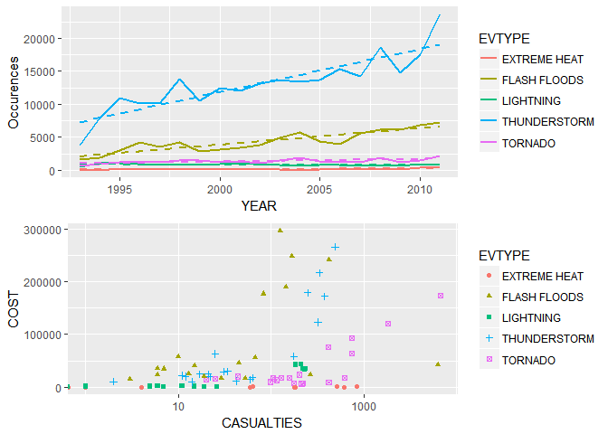

```r
grid.arrange(plot_num_events_per_year,plot_effects_scatter, nrow  = 2)
```

```r
options(scipen = 0)
```